# Section 2 Report

Michael Masterson

January 29, 2020

# Pacakges

What are packages? Packages add functionality on R.

You can install packages with the install.packages() command. This command takes the argument of the name of the package you want to install in quotes.

Lets install the “gapminder” package. This package contains data from the World Health Organization. Uncomment the following line of code, run it, then turn it back into a comment.

```r
# install.packages("gapminder")
```

If you are on your own machine rather than Rstudio Cloud, then you will also need to install the tidyverse package. This package has many functions that we will use throughout the semester.

```r
# install.packages("tidyverse")
```

## Using packages

Packages are not automatically loaded into R to save memory, so even after installing one we need to tell R we want to use it (each time we use R). This is done with the library function. The library function takes an argument of the package we want to load. Lets library the packages we just installed. I have set include=FALSE in the code chunk options, so that neither the code chunk nor its output will be included in the report we compile.

# Explore R objects

What variables are in gapminder?

```r
names(gapminder)
```

```
## [1] "country"   "continent" "year"      "lifeExp"   "pop"       "gdpPercap"
```

Lets get the summary statistics of our data.

```r
summary(gapminder)
```

```
##         country        continent        year         lifeExp
##  Afghanistan:  12   Africa  :624   Min.   :1952   Min.   :23.60
##  Albania    :  12   Americas:300   1st Qu.:1966   1st Qu.:48.20
##  Algeria    :  12   Asia    :396   Median :1980   Median :60.71
##  Angola     :  12   Europe  :360   Mean   :1980   Mean   :59.47
##  Argentina  :  12   Oceania : 24   3rd Qu.:1993   3rd Qu.:70.85
##  Australia  :  12                  Max.   :2007   Max.   :82.60
##  (Other)    :1632
##       pop              gdpPercap
##  Min.   :6.001e+04   Min.   :   241.2
##  1st Qu.:2.794e+06   1st Qu.:  1202.1
##  Median :7.024e+06   Median :  3531.8
##  Mean   :2.960e+07   Mean   :  7215.3
##  3rd Qu.:1.959e+07   3rd Qu.:  9325.5
##  Max.   :1.319e+09   Max.   :113523.1
##
```

Lets examine the first few rows of our dataframe.

```r
head(gapminder)
```

```
## # A tibble: 6 x 6
##   country     continent  year lifeExp      pop gdpPercap
##   <fct>       <fct>     <int>   <dbl>    <int>     <dbl>
## 1 Afghanistan Asia       1952    28.8  8425333      779.
## 2 Afghanistan Asia       1957    30.3  9240934      821.
## 3 Afghanistan Asia       1962    32.0 10267083      853.
## 4 Afghanistan Asia       1967    34.0 11537966      836.
## 5 Afghanistan Asia       1972    36.1 13079460      740.
## 6 Afghanistan Asia       1977    38.4 14880372      786.
```

#What if we just call our dataframe?

```r
gapminder
```

```
## # A tibble: 1,704 x 6
##    country     continent  year lifeExp      pop gdpPercap
##    <fct>       <fct>     <int>   <dbl>    <int>     <dbl>
##  1 Afghanistan Asia       1952    28.8  8425333      779.
##  2 Afghanistan Asia       1957    30.3  9240934      821.
##  3 Afghanistan Asia       1962    32.0 10267083      853.
##  4 Afghanistan Asia       1967    34.0 11537966      836.
##  5 Afghanistan Asia       1972    36.1 13079460      740.
##  6 Afghanistan Asia       1977    38.4 14880372      786.
##  7 Afghanistan Asia       1982    39.9 12881816      978.
##  8 Afghanistan Asia       1987    40.8 13867957      852.
##  9 Afghanistan Asia       1992    41.7 16317921      649.
## 10 Afghanistan Asia       1997    41.8 22227415      635.
## # … with 1,694 more rows
```

How do we refer to a specific variable in our dataframe? Use dataframe$variable_name, for example:

```r
gapminder$pop
```

That prints a lot of observations! Notice that at the beginning of the code chuck, I set results = “hide.” This means the code chuck will be included but the output will not be included when we compile our report. This is good because the output is really long and does not convey useful information to the reader.

What if we just want to know the 15th one? Variables in dataframes are vectors!

```r
gapminder$pop[15]
```

```
## [1] 1728137
```

The distinct command tells us all of the unique values of a particular variable in a dataframe. It takes two arguements: first the dataframe and second the variable name. For example, we can discover what countries are in our dataframe this way.

```r
distinct(gapminder, country)
```

```
## # A tibble: 142 x 1
##    country
##    <fct>
##  1 Afghanistan
##  2 Albania
##  3 Algeria
##  4 Angola
##  5 Argentina
##  6 Australia
##  7 Austria
##  8 Bahrain
##  9 Bangladesh
## 10 Belgium
## # … with 132 more rows
```

```r
print(distinct(gapminder, country), n = nrow(distinct(gapminder, country)))
```

```
## # A tibble: 142 x 1
##     country
##     <fct>
##   1 Afghanistan
##   2 Albania
##   3 Algeria
##   4 Angola
##   5 Argentina
##   6 Australia
##   7 Austria
##   8 Bahrain
##   9 Bangladesh
##  10 Belgium
##  11 Benin
##  12 Bolivia
```

[output cut: 130 more lines]

# Scatter Plots

What if we want to make a scatter plot of gdp Percapita and life expectancy?

We can use ggplot to make all kinds of plots, including scatter plots. The first arugment ggplot takes is what dataframe we are using. The next arguement, mapping, is what variables we are associating with each axis of our plot. The aes function within the mapping argument means aesthetics. It is necessary to include this function if we are using variables from our dataframe in our mapping.

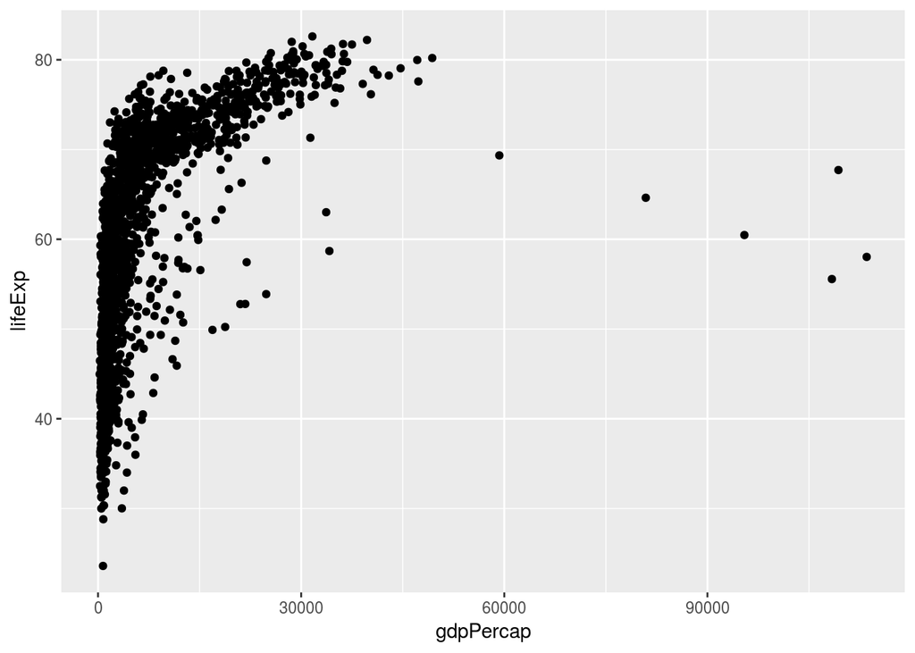

```r
ggplot(data = gapminder, mapping = aes(x = gdpPercap, y = lifeExp)) + # we aren't done yet so we need a + here
  # The thing we want to do is add points to our plot
  # We already supplied the data and mapping above, so we can just use the default arguments
  geom_point()
```

Since we are using Rmarkdown, our figure will automatically appear in the document we compile. Convenient!

Okay, but there is something odd about this plot. All of the points are bunched on the left side. This is because the relationship between gdpPercap and lifeExp is actually logarithmic rather than linear. This makes sense because once a country is wealthy enough to provide good health outcomes further wealth does not increase lifeExp much. We will go over nonlinear relationships in more detail in later sections.

Plots need labels and a title!

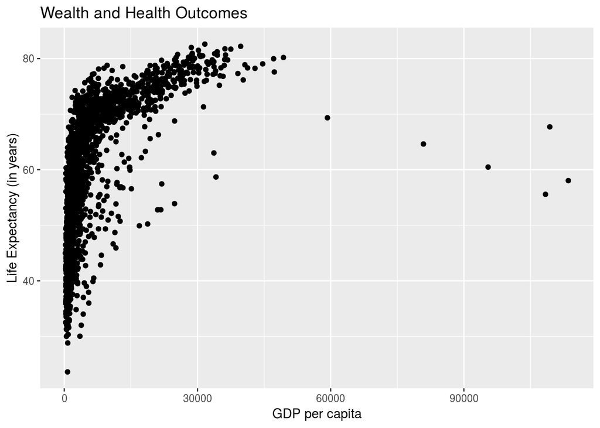

```r
ggplot(data = gapminder, mapping = aes(x = gdpPercap, y =lifeExp)) +
  geom_point() +
  #add a title
  #lable the x axis
  #lable the y axis
  labs(x = "GDP per capita", y = "Life Expectancy (in years)",
     title = "Wealth and Health Outcomes")
```

What if we want to color code by continents, like Evan did during lecture?

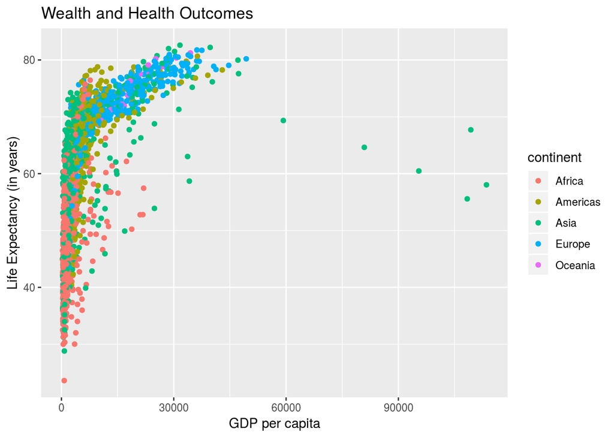

```r
ggplot(data = gapminder, mapping = aes(x = gdpPercap, y = lifeExp, color = continent)) +
  geom_point() +
  labs(x = "GDP per capita", y = "Life Expectancy (in years)",
       title = "Wealth and Health Outcomes")
```

You can also add a subtitle and a caption to your plot.

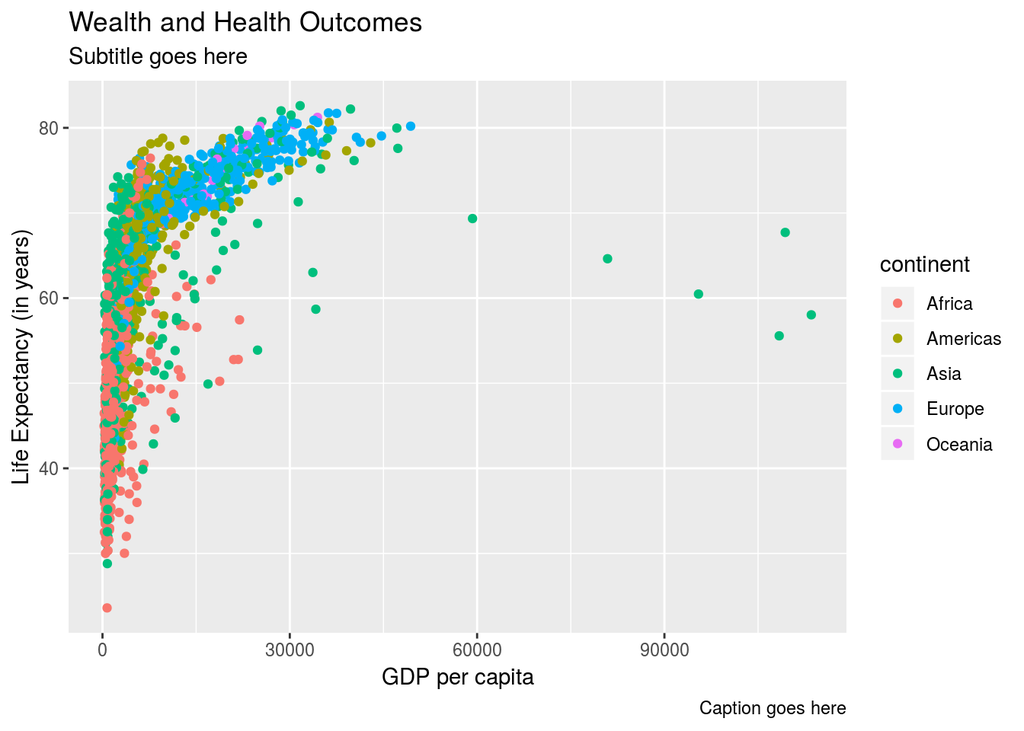

```r
ggplot(data = gapminder, mapping = aes(x = gdpPercap, y = lifeExp, color = continent)) +
  geom_point() +
  labs(x = "GDP per capita", y = "Life Expectancy (in years)",
       title = "Wealth and Health Outcomes",
       subtitle = "Subtitle goes here",
       caption = "Caption goes here")
```

Rather than color code by continents, we could also make seperate scatter plots for each continents. For some kinds of data, this might be easier to see.

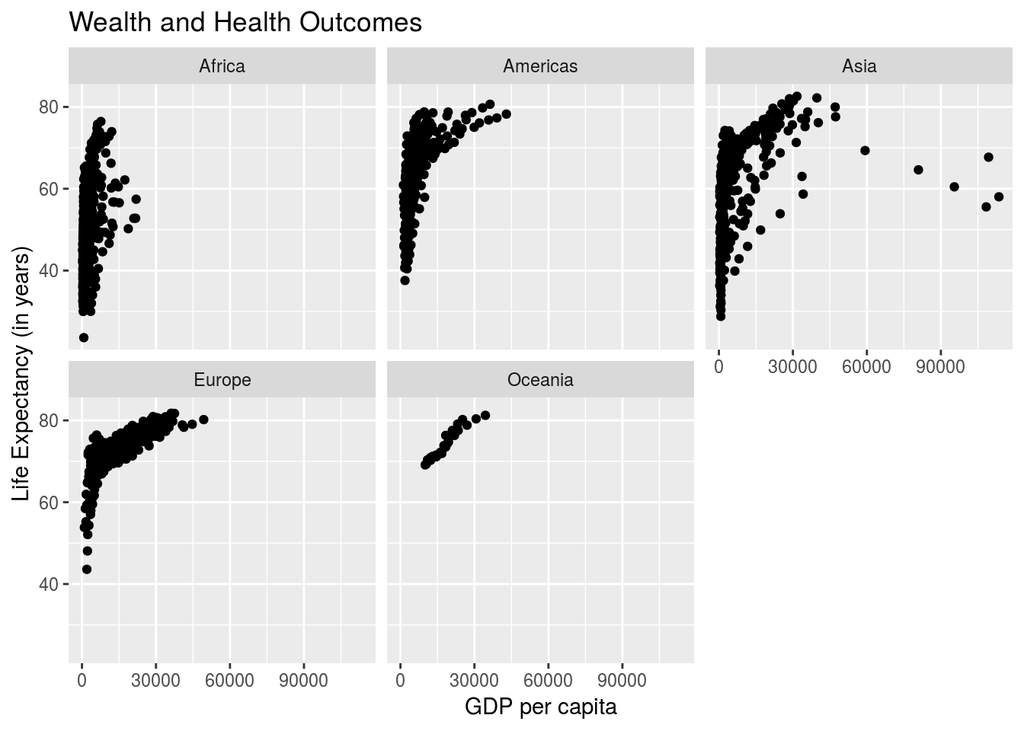

```r
ggplot(data = gapminder, mapping = aes(x = gdpPercap, y = lifeExp)) +
  geom_point() +
  #This says  make seperate plots for each continent
  facet_wrap(~ continent) +
  labs(x = "GDP per capita", y = "Life Expectancy (in years)",
       title = "Wealth and Health Outcomes")
```

# Practice 1

This is the last time I will remind you to use control+alt+i (command+option+i on Mac) to make a code chunk before starting an exercise.

1. Make a scatter plot with lifeExp as the y variable and year as the x variable
2. Give it a good title, x label and y label.

# Histograms

Histograms show how often a variable takes a value within a particular range. This may sound confusing, but you have seen this kind of plot often before and probably already have an intuitive understanding of how to interpret one. Lets make one.

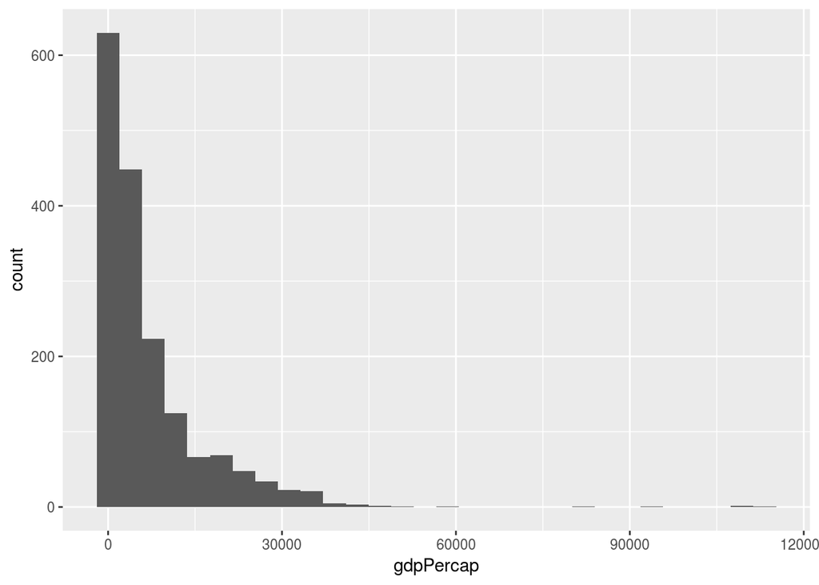

```r
ggplot(data = gapminder, mapping = aes(x = gdpPercap)) +
  geom_histogram()
```

Lets find better values for the bin widths

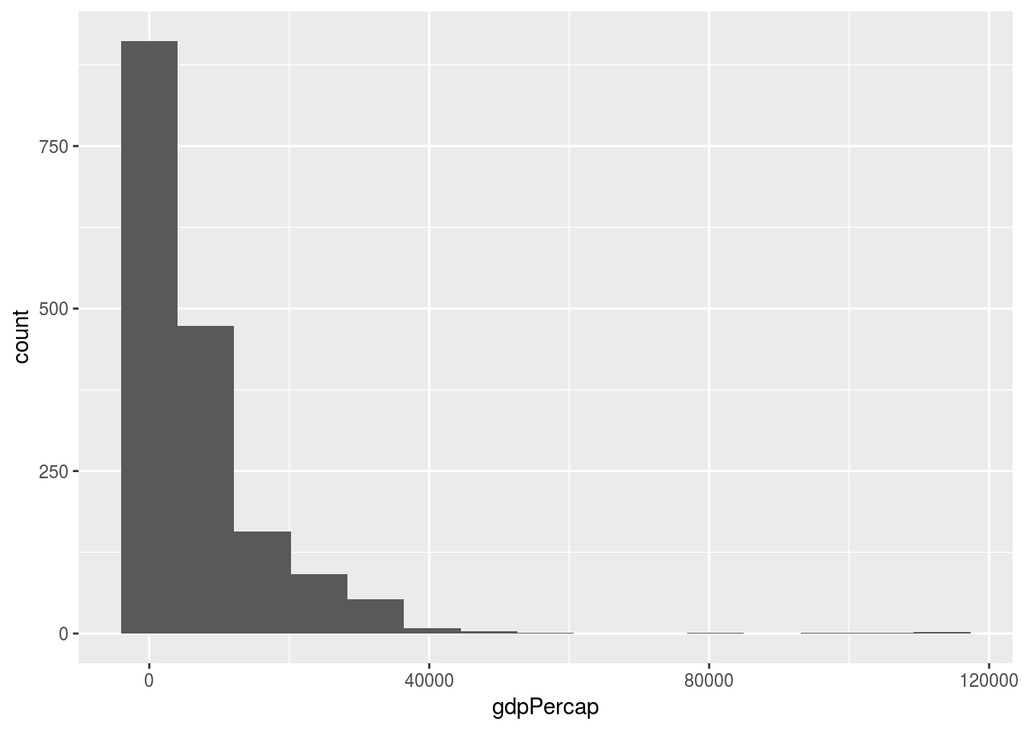

```r
ggplot(data = gapminder, mapping = aes(x = gdpPercap)) +
  #bins is an argument specific to histograms so we add it here
  geom_histogram(bins = 15)
```

What if we want to customize where the breaks are

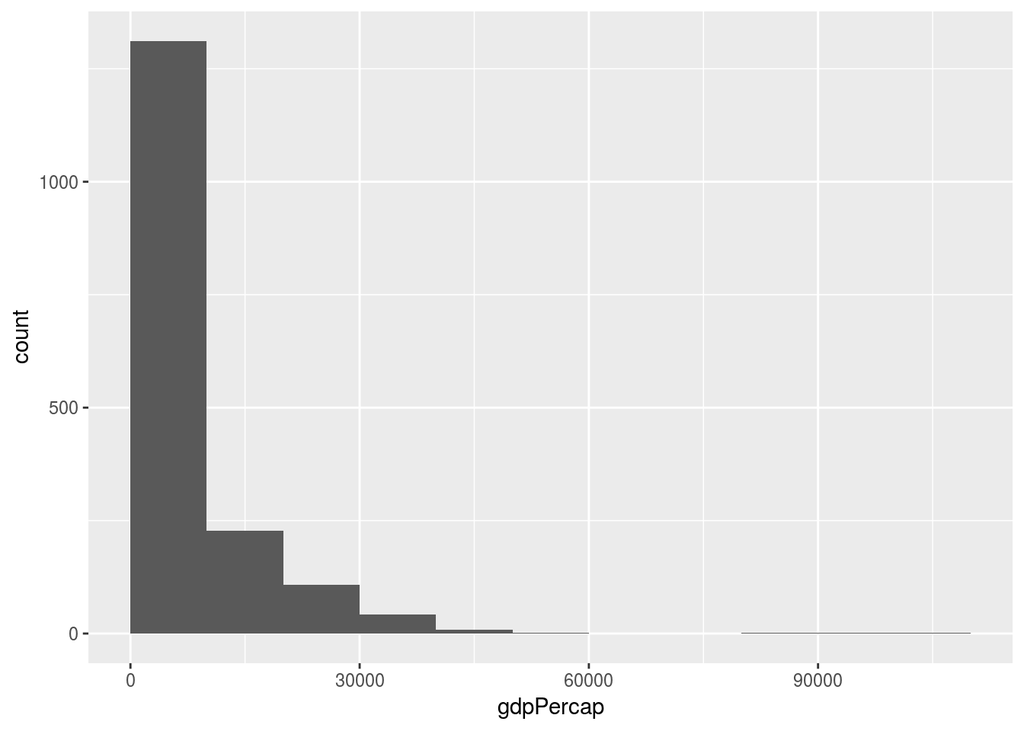

```r
ggplot(data = gapminder, mapping = aes(x = gdpPercap)) +
  #breaks is also a histogram specific arguement
  geom_histogram(breaks = seq(from = 0, to =114000, by = 10000))
```

Of course, like any plot, we need to give our histogram good labels!

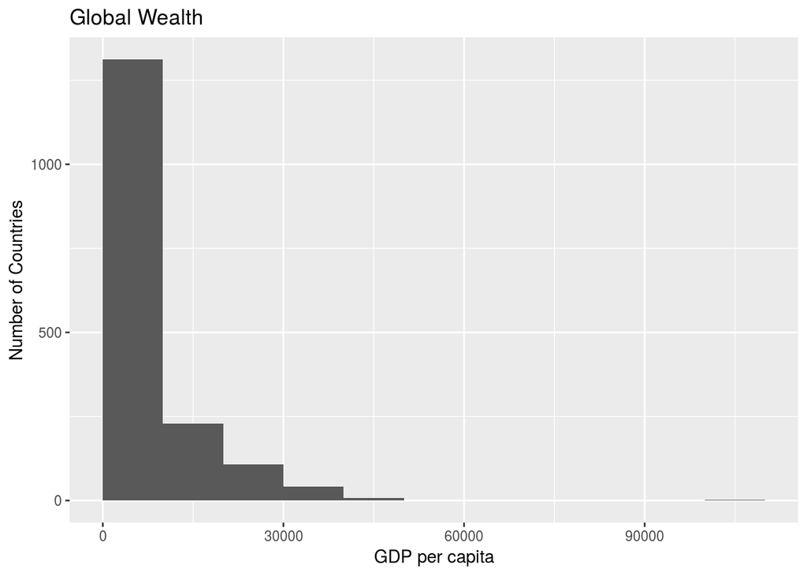

```r
ggplot(data = gapminder, mapping = aes(x = gdpPercap)) +
  geom_histogram(breaks = seq(from = 0, to =114000, by = 10000)) +
  labs(title = "Global Wealth", x = "GDP per capita",
       y = "Number of Countries")
```

We can change range of the graph along the x and y axis. Let me show you what I mean.

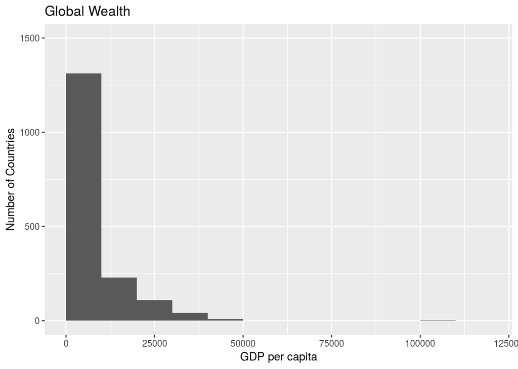

```r
ggplot(data = gapminder, mapping = aes(x = gdpPercap)) +
  geom_histogram(breaks = seq(from = 0, to = 114000, by = 10000)) +
  ggtitle("Global Wealth") +
  xlab("GDP per capita") +
  ylab("Number of Countries") +
  # This will extend the x axis to 120000 and
  # raise the  y axis to include up to 1500
  coord_cartesian(xlim = c(0, 120000), ylim = c(0, 1500))
```

# Practice 2

1. Make a histogram of lifeExp.
2. Give it a good title as well as x axis and y axis label.

# Classes of R objects

An object’s class tells you a lot of important information. It tells you what kind of functions it can serve as an argument to (functions usually only take arguments of certain kinds of classes). For variables, the class can also give you an idea of the level of measurement:

- nominal/categorical
- ordinal
- interval
- ratio

Lets examine the class of some different kinds of objects.

```r
class(5)
```

```
## [1] "numeric"
```

```r
class("word")
```

```
## [1] "character"
```

```r
class(TRUE)
```

```
## [1] "logical"
```

An object’s class also matters for operations. Can you add a word to a number? Uncomment the following line of code in this code chunk and try it out.

```r
# "word" + 2
```

This returns an error message because you cannot add 2 to a character class object.

Lets look at the classes of our variables in the gapminder data.

```r
gapminder
```

```
## # A tibble: 1,704 x 6
##    country     continent  year lifeExp      pop gdpPercap
##    <fct>       <fct>     <int>   <dbl>    <int>     <dbl>
##  1 Afghanistan Asia       1952    28.8  8425333      779.
##  2 Afghanistan Asia       1957    30.3  9240934      821.
##  3 Afghanistan Asia       1962    32.0 10267083      853.
##  4 Afghanistan Asia       1967    34.0 11537966      836.
##  5 Afghanistan Asia       1972    36.1 13079460      740.
##  6 Afghanistan Asia       1977    38.4 14880372      786.
##  7 Afghanistan Asia       1982    39.9 12881816      978.
##  8 Afghanistan Asia       1987    40.8 13867957      852.
##  9 Afghanistan Asia       1992    41.7 16317921      649.
## 10 Afghanistan Asia       1997    41.8 22227415      635.
## # … with 1,694 more rows
```

Notice how the class of each object is given in <> at the top. This is not the same as the level of measurement, but you should be able to figure out the level of measurement from the class of each variable.

What kind of R object is gapminder?

```r
class(gapminder)
```

```
## [1] "tbl_df"     "tbl"        "data.frame"
```

It is a dataframe (tbl_df and tbl are particular kinds of dataframe classes that come from tidyverse).

# Practice 3

1. What level of measurement is each variable in our dataframe?
2. What is the unit/level of analysis of the dataframe?